# 고려대학교 외국인 학생 다양성 분석

Feb.01.2020

뉴스레터 구독자 여러분 안녕하세요 :) 데이터Hub팀 데이터사이언티스트 문기범입니다. 이번 호에서는 영상 대신 글로 인사를 드립니다. 오늘은 고려대학교 외국인 학생 다양성(diversity) 분석을 소개해 드리겠습니다. 다양성은 4차산업혁명 시대의 가장 중요한 키워드 중 하나입니다. 대학 교육에서도 다양성은 매우 중요한 요소입니다. 여러 나라에서 온 학생들과 자연스럽게 교류하는 과정에서 고정관념과 편견을 극복하고 다양한 생각을 유연하게 받아들일 수 있는 개방적인 태도를 갖게 되는 것 같아요. 10여년 전에 비해 요즘에는 외국인 학생이 눈에 띄게 많아진 것 같습니다. 여러분도 그렇게 느끼시나요? 이런 느낌이 실제 분석에서는 어떻게 나타나는지 함께 확인해 보시죠!

## 사용 데이터

이번 분석에는 2006년부터 2019년까지 입학한 외국인 학생 4315명의 자료를 사용했습니다. 이 외에 편입으로 입학한 외국인 학생이 8명 있었지만, 이번 분석에 반영하지는 않았습니다. 또 아쉽게도 이번 분석은 서울 캠퍼스에 입학한 외국인 학생의 자료만을 사용하게 되었습니다.

## 외국인 학생 현황

### 외국인 학생이 얼마나 많나요?

외국인 입학생 수는 2016년 754명으로 정점을 찍은 후 감소하고 있는 추세입니다. 외국인 학생의 국적별 비중은 중국이 가장 높고 기타, 말레이시아, 미국 등이 그 뒤를 따릅니다.

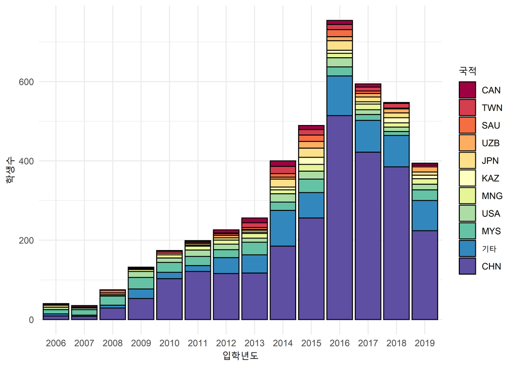

### 외국인 학생은 주로 어떤 전형을 통해 입학하나요?

전체 외국인 학생의 98.61%가 외국인 전형(정원외)을 통해 고려대학교에 입학하고 있습니다. 놀랍게도 지금까지 20명의 외국인 학생이 정시 수능을 통해 우리 고려대학교에 입학했다고 합니다. 참 대단하죠?

| 입학전형 | n | 비율(%) |
| --- | --- | --- |
| 외국인 | 4255 | 98.61 |
| Global KU | 25 | 0.58 |
| 정시_수능 | 20 | 0.46 |
| 수시_특기자 | 6 | 0.14 |
| 글로벌인재 | 4 | 0.09 |
| 순수정원외(=12년과정) | 2 | 0.05 |
| 12년과정 | 1 | 0.02 |
| 3년과정 | 1 | 0.02 |
| 수시_기회균등 | 1 | 0.02 |

### 외국인 학생은 어느 단과대학에 가장 많나요?

문과대학과 경영대학에 가장 많은 외국인 학생이 입학한 것으로 나타났습니다. 정보보호학부에 입학한 외국인 학생은 한 명도 없었습니다. 정보보호학부의 특수성이 반영된 결과로 보입니다.

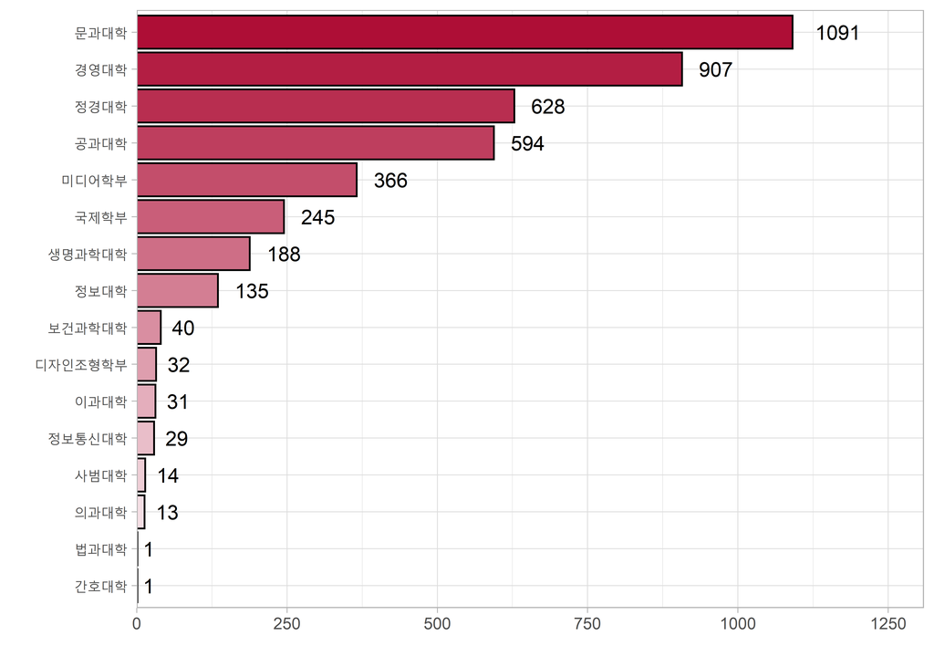

## 외국인 학생에 대한 지원이 잘 되고 있나요?

아쉽게도 분석할 수 있는 데이터 중에서 외국인 학생에 대한 지원을 정확하게 평가할 수 있는 데이터는 없었습니다. 다만, 외국인 학생들의 중도탈락율(자퇴, 제적 등)을 통해 외국인 학생들에 대한 지원을 간접적으로 평가해 보았습니다. 다행히 2010년 이후 외국인 학생들의 중도탈락율이 점점 낮아지는 추세를 보였습니다. 2018년, 2019년에 입학한 외국인 학생들의 경우 아직 저학년이라 시간이 지나면 중도탈락율이 지금보다 높아질 가능성도 있습니다. 외국인 학생들에 대한 적극적인 지원을 통해 중도탈락율 감소세가 계속 이어지길 기대해 봅니다.

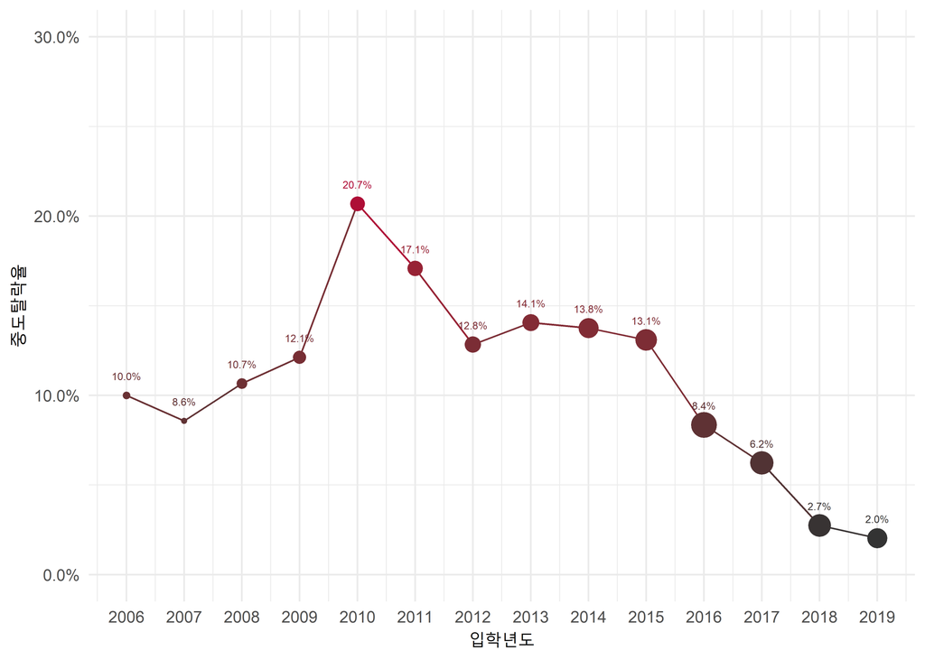

## 외국인 유학생 다양성 분석

### 생태학적 다양성

외국인 학생 다양성 분석 결과를 확인하기 앞서 생태학적 다양성 개념을 소개해 드리겠습니다. 다양성 개념은 원래 생태계 내 종 다양성을 설명하는 개념으로 제안되었습니다. 생태학에서는 생태계 내 종 다양성을 측정하기 위해 여러 지수를 개발해 활용했습니다. 최근에는 생태학 뿐만 아니라 다양한 영역에서 다양성 개념을 활용하고 있습니다. 예를 들어 전력 공급원의 구성을 분석할 때도 다양성 개념이 활용됩니다. 또 특정 기술의 융복합화 지수를 산출하거나 학문 간 융합도를 분석 분석하는 곳에도 다양성 개념이 활용되고 있습니다.

생태계의 다양성은 다종성(variety), 균등성(balance), 상이성(disparity) 등으로 구분됩니다. 다종성은 생태계 내 서로 구분되는 종의 수가 얼마나 많은 지를 의미합니다. 생태계를 구성하는 요소가 많을수록 다종성이 높아집니다. 균등성은 생태계를 구성하는 종의 분포가 얼마나 균등한 지를 말합니다. 각 종의 분포가 균일할수록 생태계의 균등성이 높아집니다. 상이성은 고생물학에서 빌려온 개념으로, 한 생태계를 이루고 있는 종이 서로 얼마나 다른 지를 말합니다. 다른 모든 조건이 동일하면, 다종성, 균등성, 상이성이 높을수록 생태계의 다양성이 높아집니다.

이제 슬슬 워밍업이 되셨을텐데요, 지금부터 본격적으로 외국인 유학생 다양성 분석 결과를 설명해 드리겠습니다 :)

### 다종성(variety) 분석

다종성은 한 생태계를 구성하는 종이 얼마나 다양한지 의미하는 개념입니다. 다종성 분석은 해당 년도에 입학한 외국인 유학생의 국적이 얼마나 다양한가 보여줄 수 있습니다. 외국인 유학생의 국적 다종성은 2016년 56개국으로 정점을 찍은 후 소폭 감소한 것으로 나타납니다.

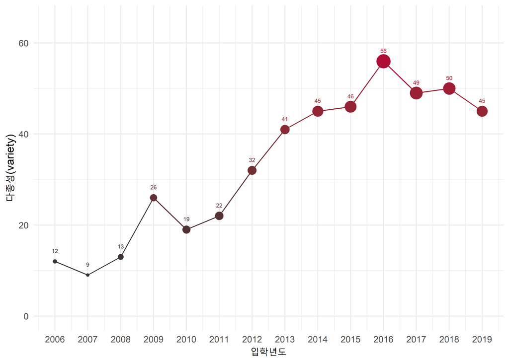

### 균등성(balance) 분석

균등성은 한 생태계를 구성하는 종의 분포가 얼마나 균일한지를 의미합니다. 균등성 분석은 고려대학교에 입학한 외국인 학생의 국적이 얼마나 고르게 분포되어 있는지 보여줍니다. 아래 plot은 외국인 학생 국적 분포에 대한 지니-심슨 지수(Gini-Simpson Index)입니다. 외국인 학생의 국적 분포가 완전히 균일할 때 1, 완전히 불균일할 때 0이 됩니다. 2006년부터 2019년까지의 평균 지니-심슨 지수는 0.68입니다. 이 평균은 아래 plot에서 검은 선으로 표시되어 있어요. 2016년부터 2018년에는 지니-심슨 지수가 다른 해에 비해 낮은 것을 확인할 수 있습니다.

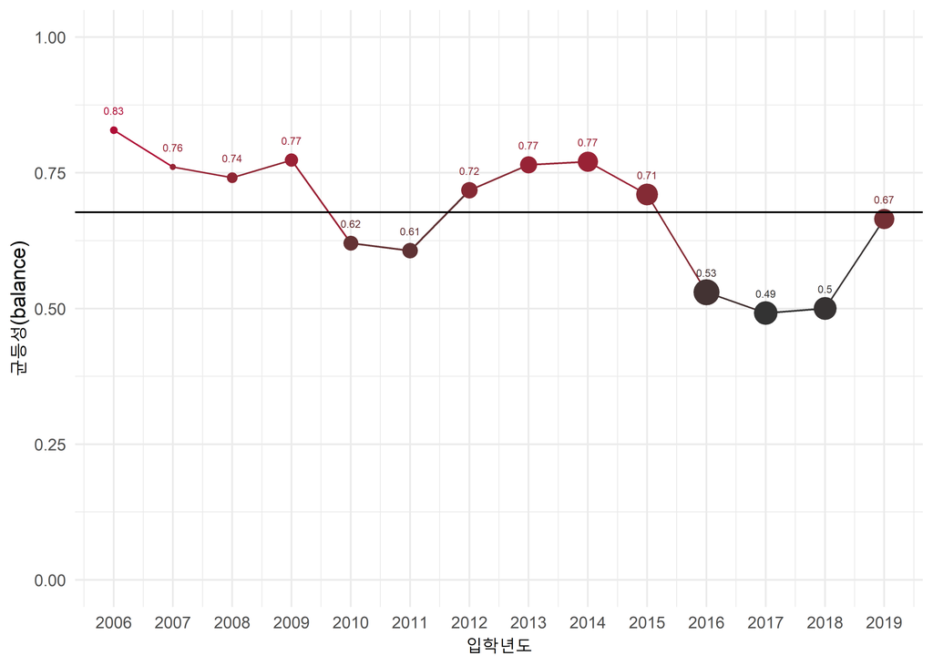

이러한 결과는 외국인 유학생의 절대적인 수가 늘어도 다양성이 늘지 않을 수 있다는 것을 보여줍니다. 특히 2016년부터 2018년 사이에는 외국인 학생의 수가 가장 많았음에도 불구하고 균등성 지수는 오히려 가장 낮았습니다. 따라서 외국인 학생의 질적 다양성을 높이기 위해서는 특정 국가에 편중된 외국인 학생의 출신국을 다변화 할 필요가 있어 보입니다. 이러한 목표를 달성하기 위해서는 학교 입장에서는 우리 학교에 진학할 확률이 높은 지역을 파악해 학생들을 유치하기 위한 전략을 수립해야할 필요가 있을 것 같습니다. 학교의 전략 수립에 도움을 주기 위해 지역별 학생수 변화 추이 대한 분석을 진행했습니다. 분석 결과 중국과 일본을 포함한 동아시아 지역 출신의 학생수가 가장 빠르게 늘고 있었습니다, B = 36.31, *p* < .001. 동아시아 지역은 지금처럼만 하면 걱정이 없을 것 같네요! 아래 plot은 동아시아 지역 이외에 학생수가 늘고 있는 지역을 보여줍니다. 중앙 아시아 지역이 조사 기간 내 학생수 증가폭이 가장 컸다, B = 2.10, *p* = .001. 동남 아시아 지역은 동아시아를 제외하고 가장 많은 학생이 유입되었을 뿐만 아니라 그 증가폭 또한 컸습니다, B = 1.91, *p* = .002. 중앙 아시아와 동남 아시아 출신 학생들의 유입이 증가하는 원인을 알아내 다른 지역에 적용하면 출신 지역 다변화에 도움이 될 수 있을 것으로 보이네요. 한편, 북아메리카와 서아시아 지역은 2016년 경까지 학생수 증가폭이 컸지만 이후 학생 유입량이 급감하고 있습니다. 해당 지역으로부터의 학생 유입을 방해하는 요인에 대한 분석이 필요할 것 같아 보입니다. 구독자분들께서는 이러한 현상이 일어난 원인을 알 것 같으신가요? 만약 그렇다면 저에게도 공유해 주세요! (a072826@korea.ac.kr)

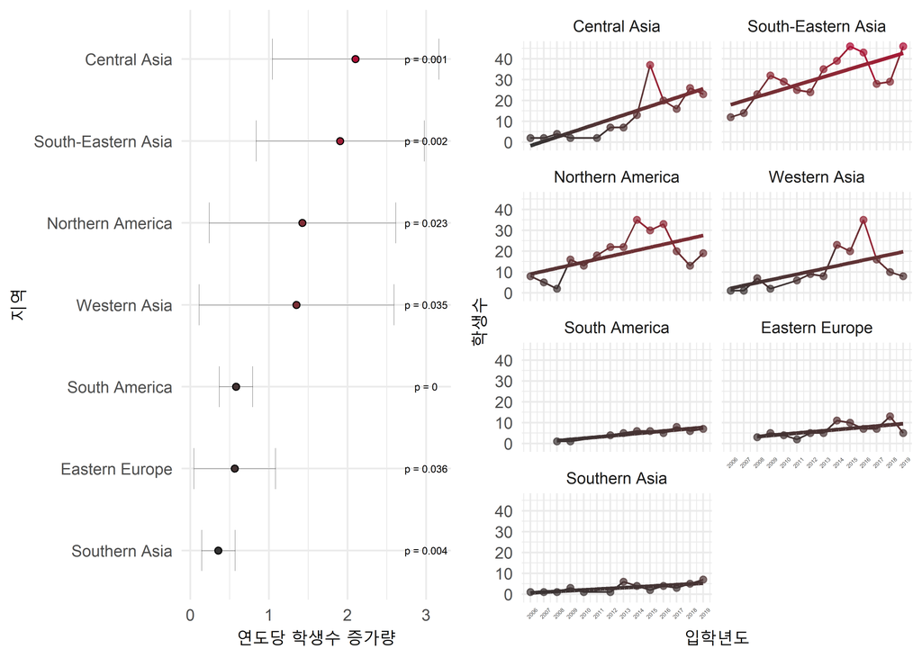

### 상이성(disparity) 분석

상이성은 한 생태계가 얼마나 이질적인 요소들로 이루어져 있는 지를 의미합니다. 생태계를 구성하는 종의 수가 많고 각 종 사이의 이질성이 높을수록 생태계의 상이성이 높아집니다. 고려대학교 외국인 학생의 출신국이 다양하고 서로 거리가 멀수록 상이성이 높아집니다. 상이성을 측정하기 위한 거리의 기준은 다양할 수 있습니다. 예를 들어 각 국가 간의 지리적 거리나 문화적 거리 등이 기준이 될 수 있습니다. 실제 다양성의 측면에서는 문화적인 거리가 지리적인 거리보다 의미가 더 클 수 있습니다. 하지만 외국인 학생들 출신 국가 간 문화적 거리를 수량화한 데이터가 없어서 지리적 거리를 상이성의 기준으로 사용했습니다. 아래 plot은 연도별 상이성의 변화를 보여줍니다. 각 상이성 점수는 해당 년도에 입학한 외국인 학생들의 출신국 사이의 지리적 거리를 모두 더한 값입니다. 2016년의 상이성이 가장 높았습니다.

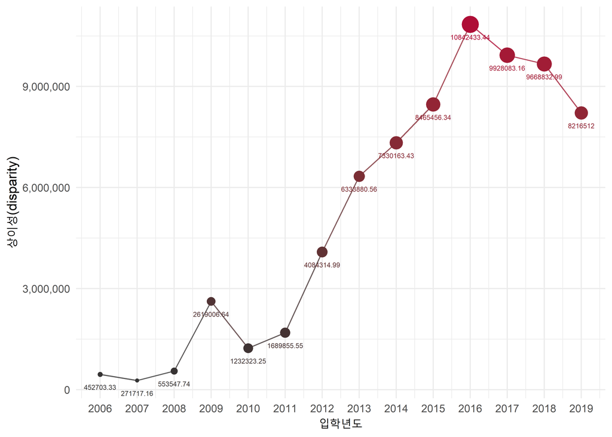

하지만 아래 plot은 상이성 지수의 한계를 보여줍니다. 상이성 지수는 종의 분포를 고려하지 않습니다. 그래서 생태계 내 개체의 대부분을 차지하는 종과 단 하나의 개체가 존재하는 종 사이의 비중이 반영되지 않습니다. 따라서 생태계를 구성하는 종의 수가 많아질수록 그에 비례해 상이성도 커지게 됩니다, *r* = .99, *p* < .001. 즉, 다종성만을 고려하는 것에 비해 추가적으로 제공하는 정보가 많지 않다는 것이죠.

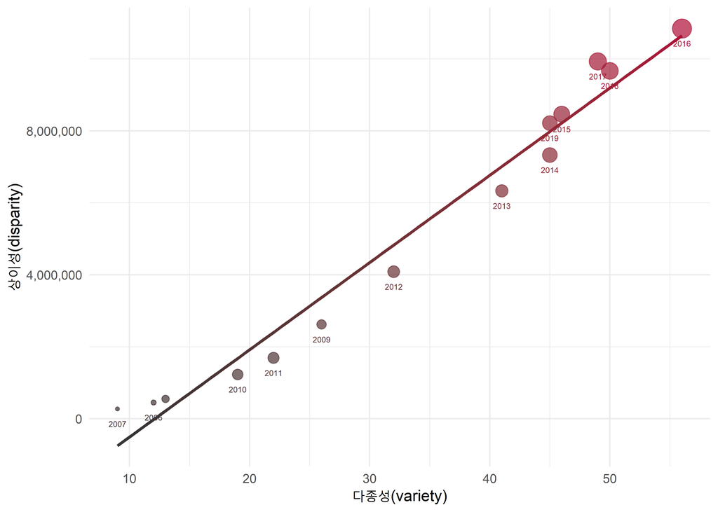

### 다양성(diversity) 분석

다양성 지수는 상이성 지수의 한계를 극복할 수 있습니다. 다양성은 균등성과 상이성을 모두 고려한 개념입니다. 다양성 지수는 서로 이질적인 종들이 얼마나 고르게 분포하는 지 종합적으로 보여줍니다. 고려대학교 외국인 학생의 다양성 분석은 얼마나 다양한 국적의 학생들이 고르게 분포하는 지 보여줍니다. 상이성 분석에서 국적별 비중이 고려되지 않은 것과 다르게 다양성 분석에서는 국적별 비중이 고려됩니다. 특정 국가 출신 외국인 학생의 비율이 높을수록 그 국가가 다양성에 미치는 영향력이 커지게 됩니다. 반면에 소수의 학생이 존재하는 국가는 그 국가가 다른 국가들과 이질적이어도 전체 다양성에 미치는 영향력이 작아집니다. 아래 plot은 연도별 다양성 지수 변화를 보여준다. 다양성 분석 결과는 외국인 유학생의 양적 증가가 다양성 증가로 이어지지 않을 수 있다는 것을 다시 한 번 보여줍니다. 다행히 2019에는 전년 대비 외국인 학생의 수는 감소하였지만 다양성 지수는 오히려 증가한 것을 확인할 수 있습니다.

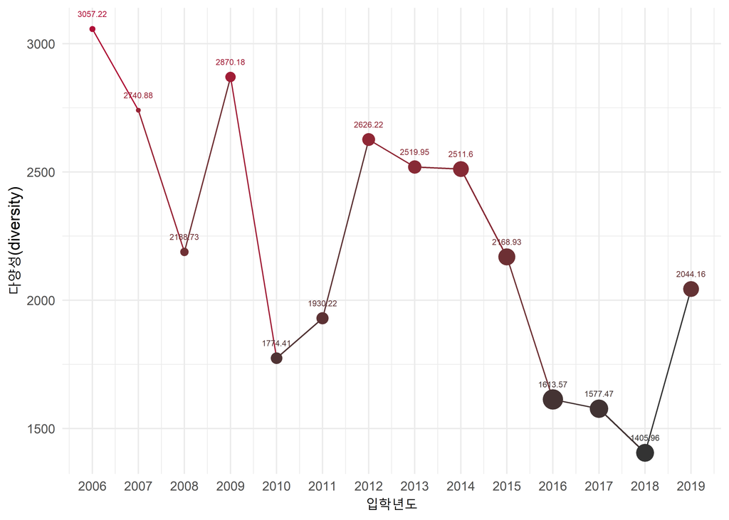

## 다채로운 고려대학교를 위하여

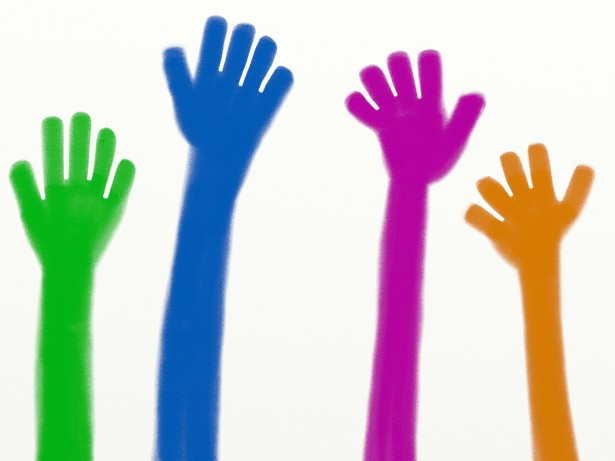

오늘은 고려대학교 외국인 학생의 다양성에 대해 살펴보았습니다. 재미있으셨나요? 다양성은 추상적인 개념입니다. 눈에 보이지 않는 다양성을 네 가지 지수(다종성, 균등성, 상이성, 다양성)를 사용해 여러 각도에서 살펴보았습니다. 다양성 분석은 외국인 학생의 국적 뿐만 아니라 다양한 영역에 적용할 수 있습니다. 예를 들어 고려대학교 교수님들의 학문 영역은 얼마나 다양할까요? 졸업생들의 진로는 얼마나 다양할까요? 고려대학교에 존재하는 동아리들은 얼마나 다양할까요? 이런 여러 다양성들이 모여 고려대학교를 더 다채롭게 만듭니다. 이번에 소개해드린 다양성 분석이 구독자분들께서 다양성에 더 관심갖게 되는 계기가 되길 바라면서 글을 마치겠습니다. 감사합니다 :)